# Money Dashboard App Insights

01/10/2019

```
## [1] 291565
```

## Project scope

### Does the type of account you add and when you add it indicate whether you are a long term user of the app?

- **3 datasets** : users, accounts and logins to provide
- Insights on users of the app
- Insight on financial institutions most and least used with the app
- Insight on app use overtime

## Considerations

- **Ignore the salary range** (too many unknown)

87% of users haven’t included their salary range.

- **Set outliers for number of accounts**

MDB support team creates a large number of accounts in order to troubleshoot user issues. These user id where removed from the analysis to avoid bias in the analysis.

- **Remove users without account** (as not using the app for the right purpose)

Some users logged in the app without having an account. These users are likely users who closed accounts or users who signed up but didnt’t add an account. These user_id were also removed from the analysis.

## Preliminary analysis… number of accounts

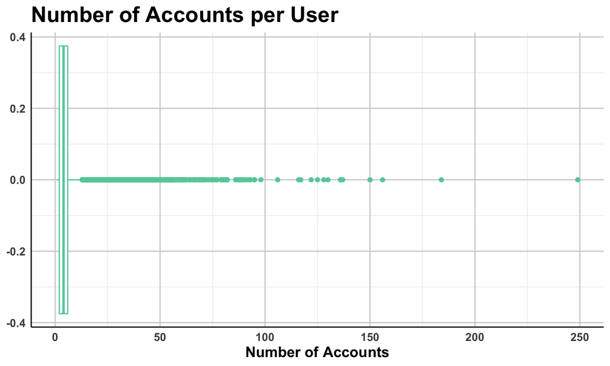

- Analysis in number of account showed:
  - Minimum number of account held: 1
  - Maximum number of accounts held: 249
  - Mean number of accounts held: 4.77

## Preliminary analysis… when are accounts opened?

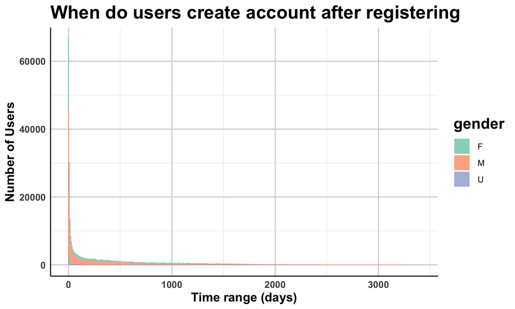

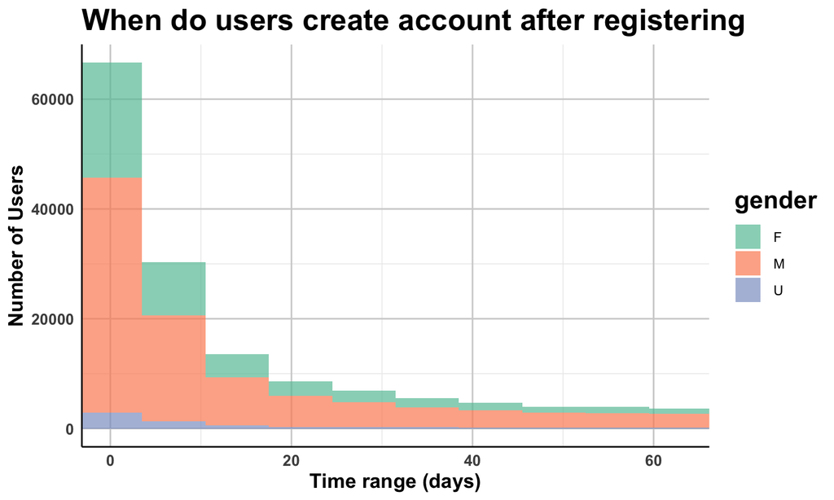

## Can we make predictions?

### Trying an automated model

[figure not shown]

### Trying the manual approach

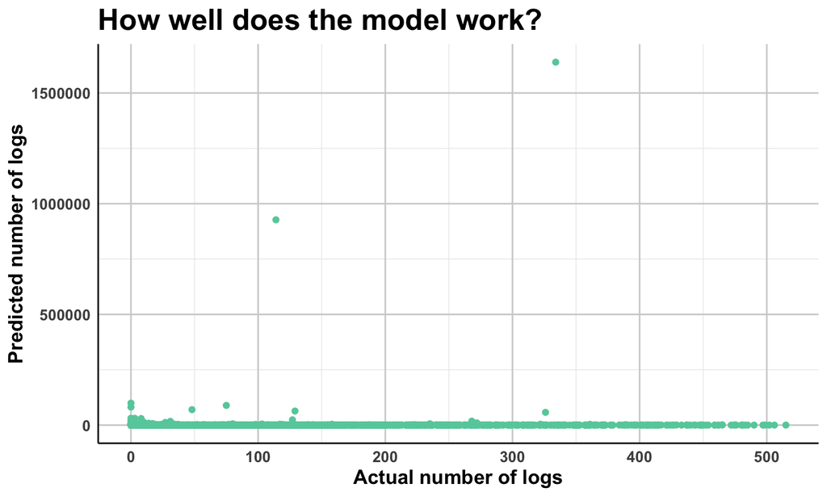

Apparently not very well

## Questions ??

[figure not shown]